# TP Bivariée

PC

3 janvier 2022

# 1 Mise en place

- Récupérer le fichier intitulé `2020_LoL_esports_match_data.csv` sur le repertoire partagé et le charger dans un dataframe
- charger les librairies `dplyr` et `ggplot2`

```r
library(ggplot2)
library(dplyr)
match_data <-  read.csv("./2020_LoL_esports_match_data.csv")
```

Le fichier contient des données de matchs d’un jeu compétitif en ligne, League of Legends, qui oppose deux équipes de 5 joueurs dans une arène. Les données sont disponibles pour chaque joueur de chaque match: une ligne décrit les caractéristiques d’un joueur lors d’un match. Le data set est assez vaste : il y a 86 000 lignes et 117 colonnes.

Deux données semblent particulièrement importantes selon les joueurs au cours d’un match : l’or gagné en chassant des créatures ou d’autres joueurs , et le nombre de jouers adverses tués par l’équipe adverse.

# 2 Corrélation

Voici par exemple le code qui permet de calculer la corrélation entre la longueur du match en secondes et la quantité d’or gagnée.

```r
cor(match_data$gamelength, match_data$totalgold)
```

```
## [1] 0.1832677
```

```r
cor.test(match_data$gamelength, match_data$totalgold)
```

```
##
##  Pearson's product-moment correlation
##
## data:  match_data$gamelength and match_data$totalgold
## t = 54.925, df = 86801, p-value < 2.2e-16
## alternative hypothesis: true correlation is not equal to 0
## 95 percent confidence interval:
##  0.1768308 0.1896889
## sample estimates:
##       cor
## 0.1832677
```

## 2.1 Exercice 1 : Variables les plus corrélées

Déterminer les variables 4 numériques (quantitatives) les plus corrélées au sens de Pearson de ce jeu de données

Voici comment ne garder que les variables numériques d’un jeu de données . Attention, il s’agit des colonnes de type ‘numérique’, ça ne signifie pas pour autant que les données sont quantitatives en elles-mêmes. (Rappellez-vous que des données qualitatives peuvent être codées avec des nombres)

```r
match_data_num <-  select(match_data, where(is.numeric))
head(match_data_num)
```

```
##   year playoffs game patch playerid gamelength result kills deaths assists
## 1 2020        0    1  9.24        1       2220      1     0      3       7
## 2 2020        0    1  9.24        2       2220      1     4      0       9
## 3 2020        0    1  9.24        3       2220      1     5      2       5
## 4 2020        0    1  9.24        4       2220      1     7      1       9
## 5 2020        0    1  9.24        5       2220      1     1      5       3
## 6 2020        0    1  9.24        6       2220      0     3      4       1
##   teamkills teamdeaths doublekills triplekills quadrakills pentakills
## 1        17         11           0           0           0          0
## 2        17         11           1           0           0          0
## 3        17         11           0           0           0          0
## 4        17         11           2           0           0          0
## 5        17         11           0           0           0          0
## 6        11         17           0           0           0          0
##   firstblood firstbloodkill firstbloodassist firstbloodvictim team.kpm   ckpm
```

[output cut: 97 more lines]

Notez également qu’avec cette fonction `select`, le deuxième argument est une clause `where` qui prend en argument un prédicat, et pas une fonction. Il s’agit du nom de la fonction **sans** les parenthèses habituelles. Techniquement , toute fonction qui renvoie une valeur booléenne peut être utilisée en tant que prédicat.

On peut supprimer d’ores et déjà certaines variables qui ne sont clairement pas quantitatives : la version du patch, l’année, et l’attribut `playoffs` qui ne contient que des valeurs 0 ou 1.

```r
#les 15 premiers noms des colonnes
head(names(match_data_num), 15)
```

```
##  [1] "year"        "playoffs"    "game"        "patch"       "playerid"
##  [6] "gamelength"  "result"      "kills"       "deaths"      "assists"
## [11] "teamkills"   "teamdeaths"  "doublekills" "triplekills" "quadrakills"
```

```r
match_data_num <-  select(match_data_num,-c(year, playoffs,patch, playerid, game, result  ))
```

Il est suggéré de suivre les étapes suivantes :

1. Obtenir la matrice de corrélation
2. Rendre la matrice de corrélation triangulaire
3. Prendre les valeurs absolues
4. trier les valeurs par ordre décroissant
5. retrouver les index des n premières valeurs
6. Former les couples de variables à partir des index

**Indices :**

- la fonction `cor` appelée sur un dataframe de valeurs **numériques** renvoie la matrice de corrélation
- utiliser le code suivant pour ne considérer que la moitié de la matrice de corrélation , et exclure les termes de la diagonales :

```r
matcor[upper.tri(matcor)] <-  NA
diag(matcor) <-  NA
```

- Utiliser la fonction `which` avcec l’argument `arr.ind=T` pour retrouver les index d’une valeur dans la matrice
- Utiliser l’argument `drop=F` pour conserver les noms de lignes et de colonnes lorsque vous accédez aux valeurs d’une matrice par les indices des lignes et colonnes
- Utiliser la fonction `sort` pour trier une collection de valeurs
- les 5 premiers éléments d’un vecteur sont obtenus en utilisant la séquence `1:5` pour indexer le vecteur (cf. TP précédent)

```r
matcor <-  cor(match_data_num)
# on ne considère qu'une moitié de la matrice , sans la diagonale
matcor[upper.tri(matcor)] <-  NA
diag(matcor) <-  NA

# 4 plus grandes valeurs de la corrélation
top4corr <- sort(matcor,decreasing = T)[1:4]

# coordonnées de la première valeur du top4
coord <- which(matcor==top4corr[1], arr.ind = T)
coord
```

```
##            row col
## earnedgold  55  54
```

```r
# valeur de la matrice avec les noms des lignes et colonnes
matcor[coord[1],coord[2], drop=F]
```

```
##            totalgold
## earnedgold  0.994074
```

```r
# coordonnées de la seconde valeur du top4
coord <- which(matcor==top4corr[2], arr.ind = T)
coord
```

```
##                       row col
## monsterkillsownjungle  63  62
```

```r
matcor[coord[1],coord[2], drop=F]
```

```
##                       monsterkills
## monsterkillsownjungle    0.9823417
```

## 2.2 Exercice 2 : Variables les moins corrélées

Réitérer le traitement précédent , mais cette fois pour extraire les 4 variables les moins corrélées.

Ces variables sont-elles utiles à analyser ? (outre le fait que les corrélations entre elles sont très faible par défintion)

```r
matcor <-  cor(match_data_num)
# on ne considère qu'une moitié de la matrice , sans la diagonale
matcor[upper.tri(matcor)] <-  NA
diag(matcor) <-  NA
matcor <-  abs(matcor)

# 4 plus petites valeurs de la corrélation
low4corr <- sort(abs(matcor))[1:4]

# coordonnées de la première valeur du top4
coord <- which(matcor==low4corr[1], arr.ind = T)
coord
```

```
##                    row col
## controlwardsbought  51   6
```

```r
# valeur de la matrice avec les noms des lignes et colonnes
matcor[coord[1],coord[2], drop=F]
```

```
##                      teamdeaths
## controlwardsbought 0.0009584477
```

```r
# coordonnées de la seconde valeur du top4
coord <- which(matcor==low4corr[2], arr.ind = T)
coord
```

```
##                    row col
## controlwardsbought  51   5
```

```r
matcor[coord[1],coord[2], drop=F]
```

```
##                       teamkills
## controlwardsbought 0.0009983081
```

Confirmer la faible corrélation par un nuage de points pour quelques couples de variables peu corrélées.

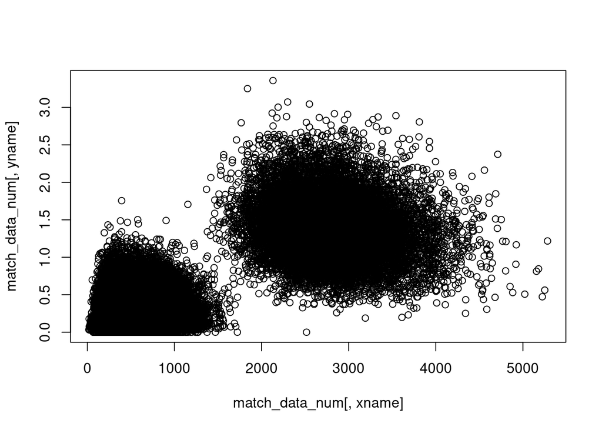

```r
#index de la nième  valeur la plus  faible de corrélations
ind <-  184

sorted_corr <- sort(abs(matcor))

coord <- which(matcor==sorted_corr[ind], arr.ind = T)
lowcorvalue <-  matcor[coord[1],coord[2], drop=F]


# extraction des noms des variables
xname <-  colnames(lowcorvalue)
yname <-  rownames(lowcorvalue)

#affichage simple
plot(match_data_num[,xname], match_data_num[,yname])
```

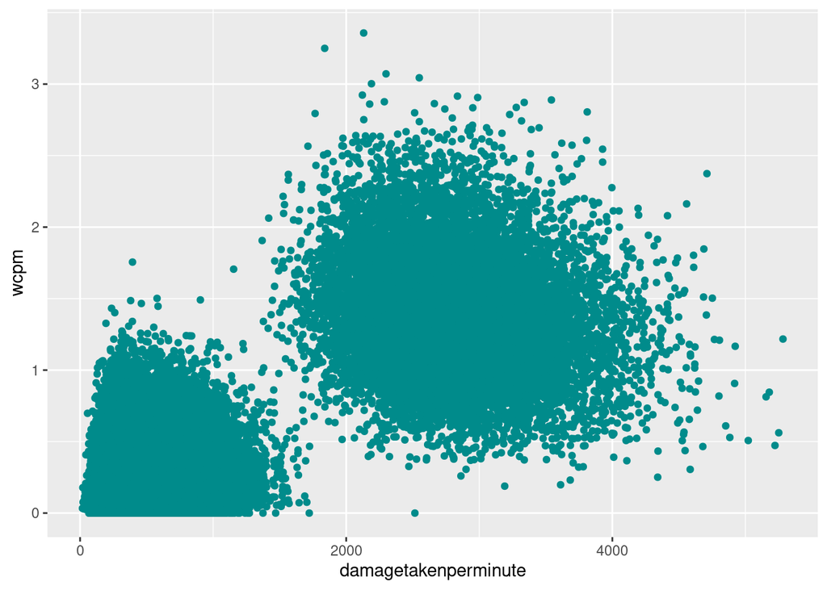

```r
# affichage avec ggplot
ggplot(match_data_num, aes_string(x = xname, y=yname))+
  geom_point(color="darkcyan")
```

Variante plus difficile laissée en exercice : faire une fonction qui génère les nuages de points de tous les couples de variables dont la corrélation est inférieure ou supérieure à un certain seuil (en valeur absolue) .

## 2.3 Exercice 3

Détecter un couple de variable pour lesquelles la corrélation de Pearson est inférieure à la corrélation de Spearman.

**indices**

- utiliser l’argument `method` de la fonction `cor()` pour changer la méthode appliquée
- les opération booléennes et de comparaison s’appliquent terme à terme aux matrices. Par exemple :

```r
#creation d'une matrice identité 5 x 5
identity5x5 <- diag(5)
identity5x5
```

```
##      [,1] [,2] [,3] [,4] [,5]
## [1,]    1    0    0    0    0
## [2,]    0    1    0    0    0
## [3,]    0    0    1    0    0
## [4,]    0    0    0    1    0
## [5,]    0    0    0    0    1
```

```r
identity5x5 == 1
```

```
##       [,1]  [,2]  [,3]  [,4]  [,5]
## [1,]  TRUE FALSE FALSE FALSE FALSE
## [2,] FALSE  TRUE FALSE FALSE FALSE
## [3,] FALSE FALSE  TRUE FALSE FALSE
## [4,] FALSE FALSE FALSE  TRUE FALSE
## [5,] FALSE FALSE FALSE FALSE  TRUE
```

```r
matcorPear <-  cor(match_data_num, method = "pearson")
matcorPear[upper.tri(matcorPear)] <-  NA
diag(matcorPear) <-  NA

matcorSpear <-  cor(match_data_num, method = "spearman")
matcorSpear[upper.tri(matcorSpear)] <-  NA
diag(matcorSpear) <-  NA


# variables pour lesquelles  pearson < spearman,
which(matcorPear < matcorSpear,arr.ind = T)
```

```
##                         row col
## kills                     2   1
## deaths                    3   1
## assists                   4   1
## teamkills                 5   1
## teamdeaths                6   1
## team.kpm                 15   1
## ckpm                     16   1
## damagetochampions        42   1
## dpm                      43   1
## damagetakenperminute     45   1
## wardsplaced              47   1
## wpm                      48   1
## wardskilled              49   1
## wcpm                     50   1
## controlwardsbought       51   1
## totalgold                54   1
## earnedgold               55   1
## earned.gpm               56   1
## monsterkills             62   1
## monsterkillsownjungle    63   1
## monsterkillsenemyjungle  64   1
## teamkills                 5   2
## team.kpm                 15   2
## ckpm                     16   2
## teamdeaths                6   3
## ckpm                     16   3
## teamkills                 5   4
## team.kpm                 15   4
## ckpm                     16   4
## team.kpm                 15   5
## damagetochampions        42   5
## dpm                      43   5
## damagetakenperminute     45   5
## wardsplaced              47   5
## wardskilled              49   5
## wcpm                     50   5
## controlwardsbought       51   5
## totalgold                54   5
## earnedgold               55   5
```

[output cut: 12 more lines]

```
## controlwardsbought       51  15
## totalgold                54  15
## earnedgold               55  15
## earned.gpm               56  15
## monsterkills             62  15
## monsterkillsownjungle    63  15
## monsterkillsenemyjungle  64  15
## damagetochampions        42  16
## dpm                      43  16
## damagetakenperminute     45  16
## earned.gpm               56  16
## dpm                      43  42
## wcpm                     50  49
## monsterkillsenemyjungle  64  62
## monsterkillsenemyjungle  64  63
```

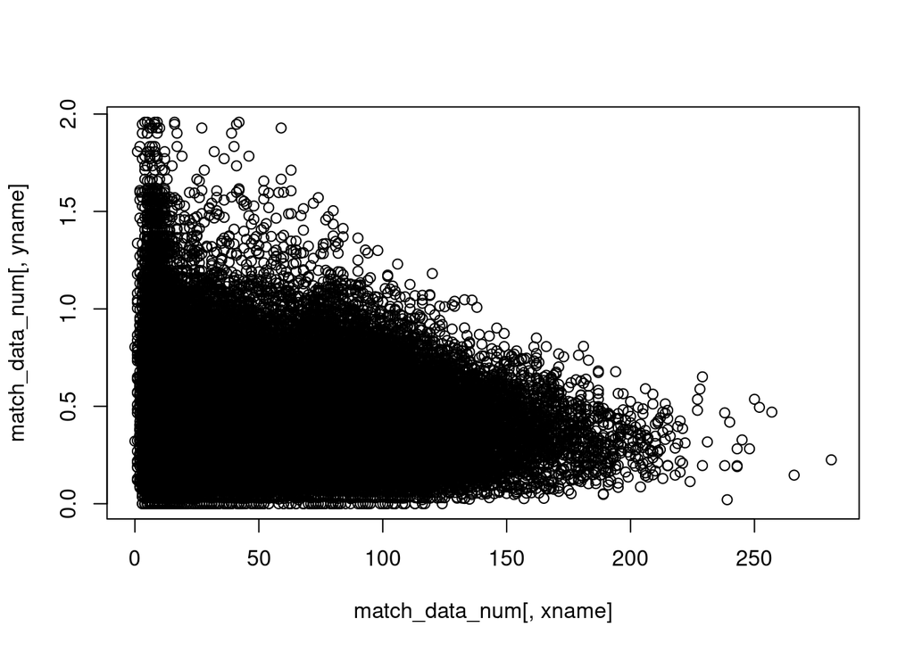

```r
# un couple au hasard
couplesretenus <-  which(matcorPear < matcorSpear, arr.ind = T)
index_hasard <-  sample(nrow(couplesretenus),1)
samplecouple <-  couplesretenus[index_hasard,]
# on récupère  les noms de lignes et de colonnes du couple au hasard

xname <-  rownames(matcorPear)[samplecouple[1]]
yname <-  rownames(matcorPear)[samplecouple[2]]


plot(match_data_num[,xname], match_data_num[,yname])
```

Peut-être peut-on formuler une hypothèse sur le fait que la corrélation linéaire est moindre par rapport à celle du rang ? (cela dépend beaucoup des variables choisies )

# 3 Régression linéaire

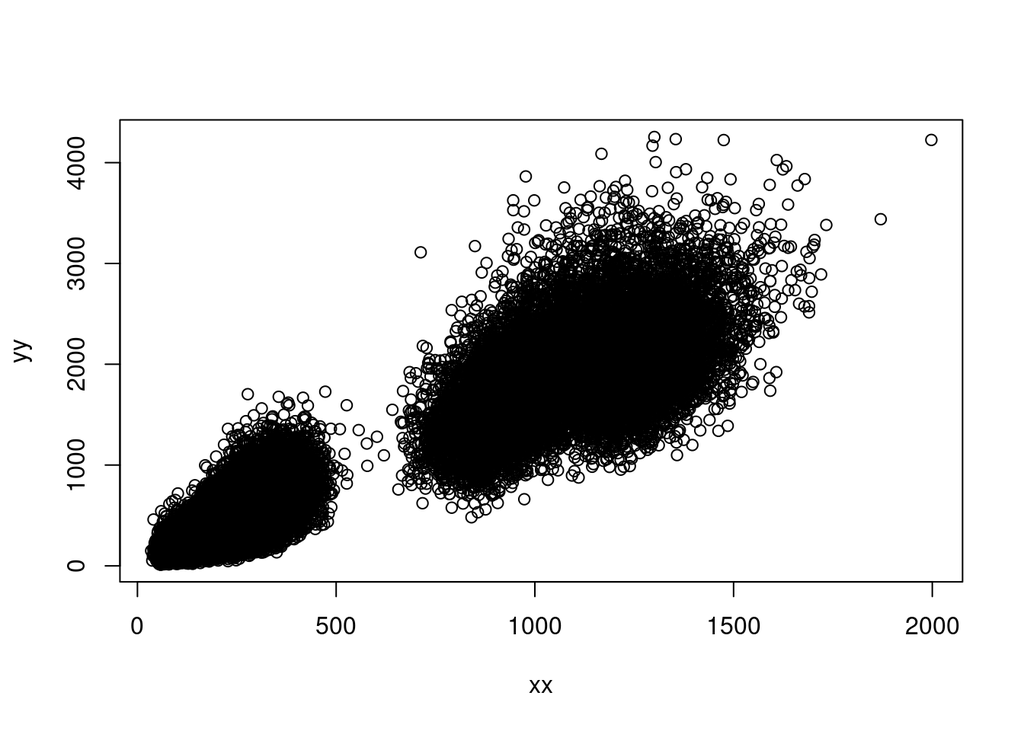

```r
matcor <-  cor(match_data_num)
# on ne considère qu'une moitié de la matrice , sans la diagonale
matcor[upper.tri(matcor)] <-  NA
diag(matcor) <-  NA

top_corr <- sort(matcor,decreasing = T)
 ind <- 10
# coordonnées de la première valeur du top4
coord <- which(matcor==top_corr[ind], arr.ind = T)
# on récupère les séries de valeurs
xx <-  match_data_num[,coord[1]]
yy <-  match_data_num[,coord[2]]

plot(xx,yy)
```

Selectionner un couple de variables dont la corrélation linéaire est élevée et tracer son nuage de points.

Voici par exemple celui des variables `dpm` et `earned.gpm`

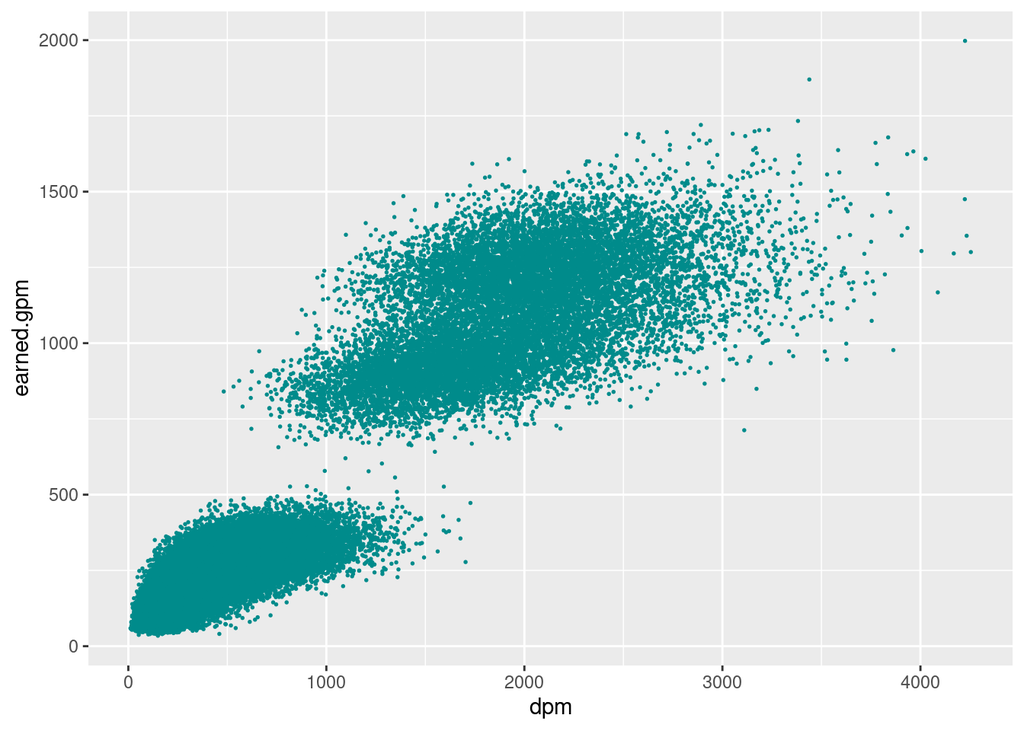

```r
ggplot(match_data_num, aes(x= dpm, y=earned.gpm))+
  geom_point(size=0.3, color="darkcyan")
```

## 3.1 Exercice 4 : regression linéaire

Réaliser la régression linéaire entre les deux variables ci-dessus (fonction `lm()`). Stocker le résultat dans une variable, ert commenter les résultats (fonction `summary`)

```r
lm1 <-  lm(match_data_num$dpm~ match_data_num$earned.gpm)
summary(lm1)
```

```
##
## Call:
## lm(formula = match_data_num$dpm ~ match_data_num$earned.gpm)
##
## Residuals:
##      Min       1Q   Median       3Q      Max
## -1279.70  -105.92   -21.93    87.26  2150.98
##
## Coefficients:
##                           Estimate Std. Error t value Pr(>|t|)
## (Intercept)               1.537202   1.072221   1.434    0.152
## match_data_num$earned.gpm 1.750750   0.002127 823.293   <2e-16 ***
## ---
## Signif. codes:  0 '***' 0.001 '**' 0.01 '*' 0.05 '.' 0.1 ' ' 1
##
## Residual standard error: 216.7 on 86801 degrees of freedom
## Multiple R-squared:  0.8865, Adjusted R-squared:  0.8865
## F-statistic: 6.778e+05 on 1 and 86801 DF,  p-value: < 2.2e-16
```

Si on suppose que la variable `earned.gpm` signifie «earned gold per minute» et que la variable `dpm` signifie «damage per minute» , il semblerait logique que plus un joueur inflige de dommage, plus il chasse de créatures et/ ou tue des adversaires, recevant ainsi de l’or.

Commenter les résultats , en particulier les p-values associées aux coefficients. Comment améliorer cela ?

## 3.2 Exercice 5 : regrouppements

D’après le graphique de la variable `dpm` et `earned.gpm`, on voit apparaître deux groupes d’individus.

Ces critères peuvent suffire à former les deux groupes. Neanmoins , vous pouvez proposer une troisième variable (ou combinaison de variables) pour former un critère qui expliquerait cette répartition en deux groupes.

```r
names(match_data)
```

```
##   [1] "gameid"                   "datacompleteness"
##   [3] "url"                      "league"
##   [5] "year"                     "split"
##   [7] "playoffs"                 "date"
##   [9] "game"                     "patch"
##  [11] "playerid"                 "side"
##  [13] "position"                 "player"
##  [15] "team"                     "champion"
##  [17] "ban1"                     "ban2"
##  [19] "ban3"                     "ban4"
##  [21] "ban5"                     "gamelength"
##  [23] "result"                   "kills"
##  [25] "deaths"                   "assists"
##  [27] "teamkills"                "teamdeaths"
##  [29] "doublekills"              "triplekills"
```

[output cut: 44 more lines]

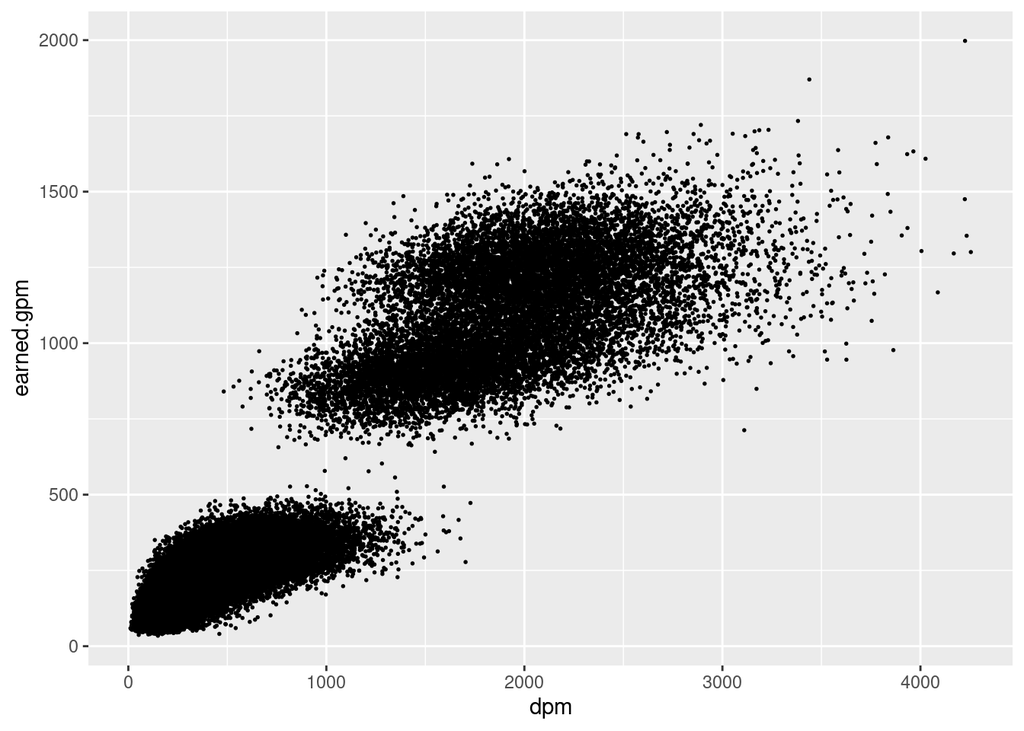

```r
ggplot(match_data, aes(x= dpm, y=earned.gpm))+
  geom_point(size=0.3)
```

Former les deux groupes d’individus et recommencer la régression linéaire. Cela amémliore-t-il les résultats ?

Dans chaque sous groupe, étudier l’influence de l’issue du match (variable `result` , numérique, mais qualitative ) sur l’or gagné par minute et les `dpm`.

# 4 Test d’indépendance du $\chi^2$

Déterminer les variables qualitatives qui semblent avoir un lien avec la variable qualitative `result`

En cas d’échec , on peut tout à fait proposer d’autres variables, par exemple basées sur des seuils, comme `match_data$earned.gpm < 500`

Attention aux messages de warning ! Dans le cas du Chi 2 , ils préviennent qu’il n’y a pas assez d’individus dans les cases du tableau de contingence pour que l’estimation soit fiable.

```r
chisq.test(match_data$result, match_data$earned.gpm < 500)
```

```
##
##  Pearson's Chi-squared test with Yates' continuity correction
##
## data:  match_data$result and match_data$earned.gpm < 500
## X-squared = 0.007482, df = 1, p-value = 0.9311
```

Quelle est la variable la plus liée au résultat du match ? Les résultats seraient-ils différents si on faisait un groupement par équipe et par match de ces données ?